# Feb 26 Class FAQ

Elgar Teo

March 01, 2021

You should take the lecture first before reading this FAQ, since some of the examples below are borrowed from the in-class activities.

## Working directory

Many of you had difficulties importing the csv file into R when doing the in-class exercise. It was because the working directory had not been set properly.

We introduced the commands `getwd()` and `setwd()` to check and change the current working directory in R respectively. But since the path of the folder that you want to change to can sometimes be too long and troublesome to type depending on how you structure and name your folders and files, let me introduce an easier way to do it graphically.

By default, R will set your home folder as the working directory to, which is represented by the symbol `~`. In macOS, the home folder is the folder of your user name (e.g., `/Users/Peter` if your user name is Peter). In Windows, the home folder is the Documents folder (e.g., `C:\Users\Peter\Documents` if your user name is Peter).

To change the working directory, you can first navigate to the target folder in the Files panel. Afterwards, click on *More* and choose *Set As Working Directory*:

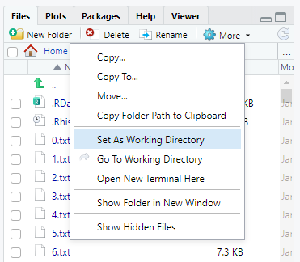

RStudio will automatically figure out the path name of the folder and run the `setwd()` command for you. Notice the path shown at the top of the Console panel has been changed:

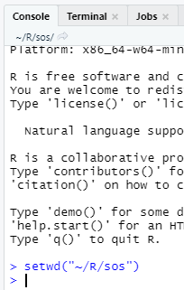

Do not drag files from the File Explorer/Finder into RStudio as an attempt to move/read files. It will not work.

## `lapply()` & `sapply()`

`lapply()` and `sapply()` in R can be hard to understand at first glance even for experienced programmers from other languages, as it is one of the characteristics of R. Indeed, it is closely related to the concept of vectorization we mentioned before.

Now, let’s consider the `Newspapers_set2` data frame from the in-class example. Suppose that we want to design a function to check whether a newspaper is a financial paper:

```r
newspaper_type <- function(x, text) {
  if (!text %in% x$name) {
    return("I don't know.") # return "I don't know." if newspaper name is not in data frame
  }
  type <- x$type[x$name == text]
  if (type == "financial") {
    paste0(text, " is a financial paper.")
  } else {
    paste0(text, " is not a financial paper.")
  }
}
newspaper_type(Newspapers_set2, "WSJ")
```

```
## [1] "WSJ is a financial paper."
```

Looks good. But when you try to fit a character vector into the function:

```r
text_vector <- c("WSJ", "Guardian", "The Sun")
newspaper_type(Newspapers_set2, text_vector)
```

```
## Warning in if (!text %in% x$name) {: the condition has length > 1 and only the
## first element will be used
```

```
## Warning in x$name == text: longer object length is not a multiple of shorter
## object length
```

```
## Error in if (type == "financial") {: argument is of length zero
```

It does not work but spills out a bunch of warning and error messages. It is because the function is designed to handle one value at a time. One solution is to use a for loop:

```r
result <- c() # an empty vector
for (i in 1:length(text_vector)) {
  result[i] <- newspaper_type(Newspapers_set2, text_vector[i])
}
result
```

```
## [1] "WSJ is a financial paper."          "Guardian is not a financial paper."
## [3] "I don't know."
```

Or you may recall the `Vectorize()` function we introduced last week:

```r
vector_newspaper_type <- Vectorize(newspaper_type, "text")
vector_newspaper_type(Newspapers_set2, text_vector)
```

```
##                                  WSJ                             Guardian
##          "WSJ is a financial paper." "Guardian is not a financial paper."
##                              The Sun
##                      "I don't know."
```

`Vectorize()` adds vectorization support to a function. How does it do that? It fits your function into a `sapply()` call under the hood (actually a bit more than just that, but same idea). In fact, you can perform the vectorization yourself without using `Vectorize()`:

```r
sapply(text_vector, function(x) { newspaper_type(Newspapers_set2, x) })
```

```
##                                  WSJ                             Guardian
##          "WSJ is a financial paper." "Guardian is not a financial paper."
##                              The Sun
##                      "I don't know."
```

Same as using `Vectorize()`!

As such, we can understand `sapply()`/`lapply()` as a function that applies an operation over a series of variables (aka a vector/list). Here is a pictorial representation:

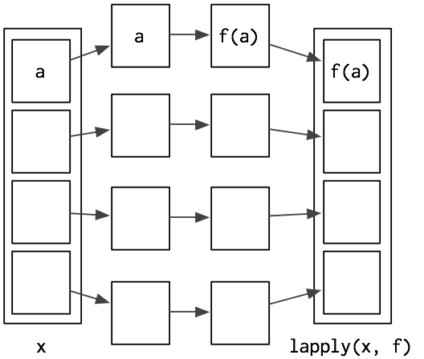

*Source: [Wickham (2014)](http://adv-r.had.co.nz/Functionals.html#lapply)*

In other words, `sapply()`/`lapply()` returns a vector/list in which:

1. the length of the output vector/list is the same as the input vector/list;
2. each element of the output vector/list is the output of the intended operation of the corresponding element of the input vector/list

A simpler way to understand `sapply()`/`lapply()` is to take it as an alternative to for loop. You may ask, why not just use a for loop? The short answer is that `sapply()`/`lapply()` almost always runs faster than a for loop. It matters a lot when you are dealing with over thousands rows of values at once.

That said, for loop is still useful in many other situations. `sapply()`/`lapply()` is good when the aim of your intended operation is to create one vector/list out of the input vector/list. If your intended operation is something other than that, for loop is the way to go.

## `lapply()` vs. `sapply()`

`sapply()` and `lapply()` are treated as the same thing in the above text. How do they differ? While they do the same thing, they output the result differently. `lapply()` always output a list containing the result (refer to [last week’s FAQ](https://elgarteo.github.io/JMSC6116-2020/feb5.html#List) if you forgot what a list is), while `sapply()` outputs a named vector:

```r
y <- lapply(text_vector, function(x) { newspaper_type(Newspapers_set2, x) })
class(y)
```

```
## [1] "list"
```

```r
y
```

```
## [[1]]
## [1] "WSJ is a financial paper."
##
## [[2]]
## [1] "Guardian is not a financial paper."
##
## [[3]]
## [1] "I don't know."
```

```r
y[[1]]
```

```
## [1] "WSJ is a financial paper."
```

```r
y <- sapply(text_vector, function(x) { newspaper_type(Newspapers_set2, x) })
class(y)
```

```
## [1] "character"
```

```r
y
```

```
##                                  WSJ                             Guardian
##          "WSJ is a financial paper." "Guardian is not a financial paper."
##                              The Sun
##                      "I don't know."
```

```r
y[1]
```

```
##                         WSJ
## "WSJ is a financial paper."
```

You can take the ‘l’ in `lapply()` as ‘listed’ and the ‘s’ in `sapply()` as ‘simplified’.

`lapply()` is useful when the output of your operation for each element of the input vector contains more than one variable because each element of a list can contain more than one variable For instance, the code on page 13 of the lecture slides outputs both the market share and the country total circulation of each newspaper as a vector. In other words, each input element will result in two output variables. Given the property of `lapply()`/`sapply()` that the length of output must equal to the length of input as mentioned above, it is not possible to use `sapply()` in this case because each element of a vector can only contain one variable. `lapply()` is therefore the way to go.

If the output of your operation is always one variable, use `sapply()`.

## How to iterate?

In the in-class example of calculating the market share of the newspapers, two different approaches were shown to complete the same task:

```r
# Option 1: iterate using a column
sapply(Newspapers_set2$name, function(x) {
  x_country <- Newspapers_set2[Newspapers_set2$name == x, ]$country
  x_circulation <- Newspapers_set2[Newspapers_set2$name == x, ]$circulation
  x_circulation / all_market[all_market$country == x_country, ]$circulation
})
# Option 2: iterate using the row number
sapply(1:nrow(Newspapers_set2), function(r) {
  x_country <- Newspapers_set2$country[r]
  x_circulation <- Newspapers_set2$circulation[r]
  x_circulation / all_market[all_market$country == x_country, ]$circulation
})
```

Both of them do the same thing. But I would personally consider Option 2 to be better. By iterating (going through the vector one-by-one) the row index number, not the name of the newspapers, there is less subsetting to be done in the code = less possible sources of errors. My generally rule of thumb is that, if the task involves computing multiple values from the same row of the data frame, it is usually better to iterate using the row number instead of a column. Again, there is no right or wrong. It is just a matter of coding style.

## Environment (optional)

The concept of environment is a bit complicated. Though I believe it will be useful since we have started using more and more customised functions in the course. It is OK if you find this part difficult to understand, since it is completely optional.

In layman terms, an environment is where variables “live” in R. For example:

```r
x <- 5
x
```

```
## [1] 5
```

The code above creates the variable `x` that carries the value `5`. If we then run:

```r
x <- 6
x
```

```
## [1] 6
```

The value of `x` is changed to `6` because variable names are unique. If we assign a value to a variable that already exists, the previous value of that variable will be overwritten.

However, this is not the case when a variable is assigned inside a function:

```r
x <- 6
test <- function(y) {
  x <- 2
  y * x
}
test(2)
```

```
## [1] 4
```

```r
x
```

```
## [1] 6
```

The variable `x` did not change to `2` even though it is reassigned as `2` in `test()`. Why?

It turns out that when a function is running, a new environment dedicated to that function is created temporarily, and any variable assignment done inside that function is only contained within that environment and not reflected in the “usual” environment, or what we call the *global environment*. This temporary environment is destroyed upon completion of function runtime. For instance:

```r
test <- function(y) {
  z <- 2
  y * z
}
test(2)
```

```
## [1] 4
```

```r
z
```

```
## Error in eval(expr, envir, enclos): object 'z' not found
```

`z` is not found in the global environment because it is assigned inside `test()`, and destroyed when `test()` has finished running.

It is worth mentioning that while variables created inside a function is not accessible outside the function, variables in the global environment can be accessed inside a function:

```r
test <- function(y) {
  y * z
}
test(2) # error because z is nowhere to be found
```

```
## Error in test(2): object 'z' not found
```

```r
z <- 2 # assign z in global environment
test(2)
```

```
## [1] 4
```

Looking back at the in-class example on calculating the market share of the newspapers, we can now understand why `x_country` and `x_circulation` does not exist in the global environment after running the `sapply()`/`lapply()` code.

Because of this property, *sometimes* it is better off using for loop than `sapply()`/`lapply()` when creating a vector/list out of an existing vector. Variables created inside a for loop are all stored in the global environment, while variables created during the `sapply()`/`lapply()` operation are stored in a temporary environment. If your operation is error-prone, you may want to use a for loop instead so that the partially-processed data can be preserved in the case of an error. One example is when doing continuous API calls. Consider the following fictional code that iterates through page 1 to 60 in retrieving data from some API:

```r
# Version A: for loop version
result <- c() # an empty vector
for (i in 1:60) {
  Sys.sleep(2)
  result[i] <- api_call(i)
}
# Version B: sapply version
result <- sapply(1:60, function(i) {
  Sys.sleep(2)
  api_call(i)
})
```

Theoretically speaking, both versions achieve the same result. But say if your computer loses connection to the API server in the middle of downloading page 58, e.g., you accidentally disconnect the WiFi connection or the API server is too busy and drops your connection, you would have to re-download page 1 to 60 all over again for Version B because all the previously-retrieved data is stored inside the temporary environment that has been destroyed when `api_call()` encountered a connection error. In contrast, you would only have to modify the for loop to restart from page 58 onwards for Version A, because the previously-retrieved data is stored inside the global environment, unaffected by the connection error.

In such cases, using a for loop is better than `sapply()`/`lapply()`. This is why the in-class examples that involve data retrieval from the internet always use for loop.